# New York Mayoral Election 2017

Group A

1/26/2022

## Introduction

An election for Mayor of New York City was held on November 7, 2017.

> ‘Incumbent Democrat Bill de Blasio won reelection to a second term with 66.2% of the vote against Republican Nicole Malliotakis.’ [^1]

This following exercise will show the results of the election in tables.

## Data presented as a table

New York Mayoral Election 2017

| Borough | Candidate de Balsio | Candidate Malliotakis | Candidate Other |
| --- | --- | --- | --- |
| Bronx | 117712 | 23715 | 3138 |
| Brooklyn | 254755 | 74343 | 10602 |
| Manhattan | 190312 | 53853 | 10186 |
| Queens | 171867 | 94911 | 8974 |
| Staten Island | 25466 | 70125 | 2747 |
| Total | 760112 | 316947 | 35647 |

Source: CNN

## Data presented as a bar plot

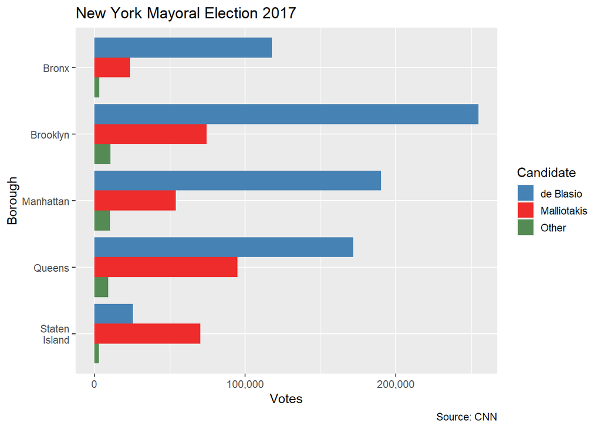

## What is better: table or bar plot?

Advantages of a table:

- Ability to know the exact values for each data point.
- The data will be organised such that the data for each candidate is grouped together in one column, making it easy to locate which data point you want to look at according to the borough.

Disadvantages of a table:

- Inability to instantly read trends for the candidates over different boroughs.
- Readers may not be able to know which candidate has the most votes at a quick glance.

Advantages of a bar plot:

- Readers are able to visualize the data for each candidate at a glance, thus, conveniently knowing each candidate has the most or least votes for each Borough.
- This also leads to the data being easily understood among a wider audience.
- Each bar can also be filled with color, making the trends bold and clear for every candidate.
- In the bar chart shown above, the colors, blue, red, and green are distinguished easily from each other, enabling easier interpretations of the data.

Disadvantages of a bar plot:

- Not being able to know the exact number of votes each candidate has, only a rough gauge on where the number lies along the x-axis.
- Additionally, having different data sets plotted on the same bar plot means that some data sets might get ‘squished’ (e.g. differences in the ‘Other’ borough cannot be seen clearly because the scale is dominated by the larger ‘de Blasio’ borough data).
[^1]: https://en.wikipedia.org/wiki/2017_New_York_City_mayoral_election Accessed on 26/1/2022